# S2.4 Baseline latent structural equation model

Kunru Song

2026-07-18 18:29:40 +08:00

Existing RDA object identifiers are retained for compatibility. Mplus folders, run-file prefixes, reports, tables and figures use the current analysis numbering.

# 1 Scientific question and model design

This analysis tests whether baseline Trait Peripheral and Trait Core PSMU factors are associated with latent baseline depression, anxiety, and perceived stress. All five constructs are represented by their raw items rather than scale totals.

Two models are estimated with local Mplus 8.7 through R `MplusAutomation`:

1. a five-factor measurement model in which all latent factors correlate;
2. a structural model in which latent depression, anxiety, and perceived stress are simultaneously regressed on latent Peripheral and Core.

The structural model freely estimates the Peripheral–Core covariance and the residual covariances among the three endogenous outcome factors. This allows depression, anxiety, and stress to remain associated after accounting for PSMU. With these residual covariances, the two models are covariance-equivalent parameterizations and should have identical global fit; the structural model supplies the mutually adjusted regression paths.

The 42 indicators are treated as ordered categorical with WLSMV and Delta parameterization, matching the primary baseline CFA estimator. The documented anxiety shift and perceived-stress reversals are applied only to the generated S2.4 analysis data; the canonical S2.1 raw-item RDA is not modified.

# 2 Load and validate the expanded S2.1 baseline entry

```r
dat_step2_measurement <- load_single_object(
  measurement_file,
  "dat_step2_measurement"
)

psmu_items <- paste0("V_BSMAS_", 1:18)
depression_items <- paste0("K_CESD_", 1:7)
anxiety_items <- paste0("L_DASS_", 1:7)
stress_items <- paste0("M_PSS_", 1:10)
all_model_items <- c(
  psmu_items,
  depression_items,
  anxiety_items,
  stress_items
)
required_columns <- c("Name_ID", all_model_items)

dat_baseline_raw <- dat_step2_measurement$baseline |>
  dplyr::select(dplyr::all_of(required_columns)) |>
  as.data.frame()

stopifnot(
  identical(
    names(dat_step2_measurement),
    c("baseline", "ema", "item_map", "audit")
  ),
  nrow(dat_step2_measurement$baseline) == 209L,
  ncol(dat_step2_measurement$baseline) == 43L,
  nrow(dat_step2_measurement$item_map) == 48L,
  identical(names(dat_baseline_raw), required_columns),
  nrow(dat_baseline_raw) == 209L,
  dplyr::n_distinct(dat_baseline_raw$Name_ID) == 209L,
  !anyNA(dat_baseline_raw),
  all(vapply(dat_baseline_raw[psmu_items], function(x) all(x %in% 1:5), logical(1))),
  all(vapply(dat_baseline_raw[depression_items], function(x) all(x %in% 1:4), logical(1))),
  all(vapply(dat_baseline_raw[anxiety_items], function(x) all(x %in% 1:4), logical(1))),
  all(vapply(dat_baseline_raw[stress_items], function(x) all(x %in% 1:5), logical(1)))
)

input_audit <- data.frame(
  participants = nrow(dat_baseline_raw),
  raw_items = length(all_model_items),
  missing_item_cells = sum(is.na(dat_baseline_raw[all_model_items])),
  measurement_rda_md5 = unname(tools::md5sum(measurement_file)),
  generated_by = dat_step2_measurement$audit$generated_by,
  stringsAsFactors = FALSE
)

knitr::kable(input_audit)
```

| participants | raw_items | missing_item_cells | measurement_rda_md5 | generated_by |
| --- | --- | --- | --- | --- |
| 209 | 42 | 0 | 96e2c717ca280b21f3eab023b06698a5 | Step_2_Measurement_Models/S2_1_Prepare.Rmd |

# 3 Apply the documented analysis-only transformations

```r
dat_baseline_sem <- dat_baseline_raw
dat_baseline_sem[anxiety_items] <- lapply(
  dat_baseline_sem[anxiety_items],
  function(x) x - 1
)
stress_reverse_items <- c("M_PSS_4", "M_PSS_5", "M_PSS_7", "M_PSS_8")
dat_baseline_sem[stress_reverse_items] <- lapply(
  dat_baseline_sem[stress_reverse_items],
  function(x) 6 - x
)

mplus_names <- c(
  paste0("bs", 1:18),
  paste0("d", 1:7),
  paste0("a", 1:7),
  paste0("s", 1:10)
)
constructs <- c(
  rep("Trait PSMU", 18),
  rep("Depression", 7),
  rep("Anxiety", 7),
  rep("Perceived stress", 10)
)
factor_names <- c(
  rep(c("PERIPH", "CORE"), c(6, 12)),
  rep("DEP", 7),
  rep("ANX", 7),
  rep("STR", 10)
)
transformations <- c(
  rep("Raw 1-5", 18),
  rep("Raw 1-4", 7),
  rep("Shifted from 1-4 to 0-3 using x - 1", 7),
  ifelse(
    stress_items %in% stress_reverse_items,
    "Reverse-scored using 6 - x",
    "Raw 1-5"
  )
)

variable_map <- data.frame(
  item_order = seq_along(all_model_items),
  project_variable = all_model_items,
  mplus_variable = toupper(mplus_names),
  construct = constructs,
  factor = factor_names,
  transformation = transformations,
  stringsAsFactors = FALSE
)

mplus_data <- dat_baseline_sem[all_model_items]
names(mplus_data) <- mplus_names
mplus_data <- as.data.frame(mplus_data)

stopifnot(
  identical(names(mplus_data), mplus_names),
  nrow(mplus_data) == 209L,
  !anyNA(mplus_data),
  all(vapply(mplus_data[paste0("bs", 1:18)], function(x) all(x %in% 1:5), logical(1))),
  all(vapply(mplus_data[paste0("d", 1:7)], function(x) all(x %in% 1:4), logical(1))),
  all(vapply(mplus_data[paste0("a", 1:7)], function(x) all(x %in% 0:3), logical(1))),
  all(vapply(mplus_data[paste0("s", 1:10)], function(x) all(x %in% 1:5), logical(1))),
  length(unique(substr(mplus_names, 1L, 8L))) == 42L
)

transformation_audit <- variable_map |>
  dplyr::group_by(construct, transformation) |>
  dplyr::summarise(items = dplyr::n(), .groups = "drop")

knitr::kable(transformation_audit)
```

| construct | transformation | items |
| --- | --- | --- |
| Anxiety | Shifted from 1-4 to 0-3 using x - 1 | 7 |
| Depression | Raw 1-4 | 7 |
| Perceived stress | Raw 1-5 | 6 |
| Perceived stress | Reverse-scored using 6 - x | 4 |
| Trait PSMU | Raw 1-5 | 18 |

```r
knitr::kable(variable_map)
```

| item_order | project_variable | mplus_variable | construct | factor | transformation |
| --- | --- | --- | --- | --- | --- |
| 1 | V_BSMAS_1 | BS1 | Trait PSMU | PERIPH | Raw 1-5 |
| 2 | V_BSMAS_2 | BS2 | Trait PSMU | PERIPH | Raw 1-5 |
| 3 | V_BSMAS_3 | BS3 | Trait PSMU | PERIPH | Raw 1-5 |
| 4 | V_BSMAS_4 | BS4 | Trait PSMU | PERIPH | Raw 1-5 |
| 5 | V_BSMAS_5 | BS5 | Trait PSMU | PERIPH | Raw 1-5 |
| 6 | V_BSMAS_6 | BS6 | Trait PSMU | PERIPH | Raw 1-5 |
| 7 | V_BSMAS_7 | BS7 | Trait PSMU | CORE | Raw 1-5 |
| 8 | V_BSMAS_8 | BS8 | Trait PSMU | CORE | Raw 1-5 |
| 9 | V_BSMAS_9 | BS9 | Trait PSMU | CORE | Raw 1-5 |
| 10 | V_BSMAS_10 | BS10 | Trait PSMU | CORE | Raw 1-5 |
| 11 | V_BSMAS_11 | BS11 | Trait PSMU | CORE | Raw 1-5 |
| 12 | V_BSMAS_12 | BS12 | Trait PSMU | CORE | Raw 1-5 |
| 13 | V_BSMAS_13 | BS13 | Trait PSMU | CORE | Raw 1-5 |
| 14 | V_BSMAS_14 | BS14 | Trait PSMU | CORE | Raw 1-5 |
| 15 | V_BSMAS_15 | BS15 | Trait PSMU | CORE | Raw 1-5 |
| 16 | V_BSMAS_16 | BS16 | Trait PSMU | CORE | Raw 1-5 |
| 17 | V_BSMAS_17 | BS17 | Trait PSMU | CORE | Raw 1-5 |
| 18 | V_BSMAS_18 | BS18 | Trait PSMU | CORE | Raw 1-5 |
| 19 | K_CESD_1 | D1 | Depression | DEP | Raw 1-4 |
| 20 | K_CESD_2 | D2 | Depression | DEP | Raw 1-4 |
| 21 | K_CESD_3 | D3 | Depression | DEP | Raw 1-4 |
| 22 | K_CESD_4 | D4 | Depression | DEP | Raw 1-4 |
| 23 | K_CESD_5 | D5 | Depression | DEP | Raw 1-4 |
| 24 | K_CESD_6 | D6 | Depression | DEP | Raw 1-4 |
| 25 | K_CESD_7 | D7 | Depression | DEP | Raw 1-4 |
| 26 | L_DASS_1 | A1 | Anxiety | ANX | Shifted from 1-4 to 0-3 using x - 1 |
| 27 | L_DASS_2 | A2 | Anxiety | ANX | Shifted from 1-4 to 0-3 using x - 1 |
| 28 | L_DASS_3 | A3 | Anxiety | ANX | Shifted from 1-4 to 0-3 using x - 1 |
| 29 | L_DASS_4 | A4 | Anxiety | ANX | Shifted from 1-4 to 0-3 using x - 1 |
| 30 | L_DASS_5 | A5 | Anxiety | ANX | Shifted from 1-4 to 0-3 using x - 1 |
| 31 | L_DASS_6 | A6 | Anxiety | ANX | Shifted from 1-4 to 0-3 using x - 1 |
| 32 | L_DASS_7 | A7 | Anxiety | ANX | Shifted from 1-4 to 0-3 using x - 1 |
| 33 | M_PSS_1 | S1 | Perceived stress | STR | Raw 1-5 |
| 34 | M_PSS_2 | S2 | Perceived stress | STR | Raw 1-5 |
| 35 | M_PSS_3 | S3 | Perceived stress | STR | Raw 1-5 |
| 36 | M_PSS_4 | S4 | Perceived stress | STR | Reverse-scored using 6 - x |
| 37 | M_PSS_5 | S5 | Perceived stress | STR | Reverse-scored using 6 - x |
| 38 | M_PSS_6 | S6 | Perceived stress | STR | Raw 1-5 |
| 39 | M_PSS_7 | S7 | Perceived stress | STR | Reverse-scored using 6 - x |
| 40 | M_PSS_8 | S8 | Perceived stress | STR | Reverse-scored using 6 - x |
| 41 | M_PSS_9 | S9 | Perceived stress | STR | Raw 1-5 |
| 42 | M_PSS_10 | S10 | Perceived stress | STR | Raw 1-5 |

# 4 Specify the measurement and structural models

```r
measurement_syntax <- paste(
  "periph BY bs1-bs6;",
  "core BY bs7-bs18;",
  "dep BY d1-d7;",
  "anx BY a1-a7;",
  "str BY s1-s10;",
  "periph WITH core dep anx str;",
  "core WITH dep anx str;",
  "dep WITH anx str;",
  "anx WITH str;",
  sep = "\n"
)

structural_syntax <- paste(
  "periph BY bs1-bs6;",
  "core BY bs7-bs18;",
  "dep BY d1-d7;",
  "anx BY a1-a7;",
  "str BY s1-s10;",
  "dep anx str ON periph core;",
  "periph WITH core;",
  "dep WITH anx str;",
  "anx WITH str;",
  sep = "\n"
)

model_specs <- list(
  Measurement_5Factor = list(
    label = "Five-factor measurement model",
    stem = "s2_4_measurement_5factor",
    model = measurement_syntax,
    structural = FALSE
  ),
  Structural_CorePeripheral = list(
    label = "Core and Peripheral predicting three latent outcomes",
    stem = "s2_4_structural_core_peripheral",
    model = structural_syntax,
    structural = TRUE
  )
)

model_plan <- dplyr::bind_rows(lapply(names(model_specs), function(model_id) {
  specification <- model_specs[[model_id]]
  data.frame(
    model_id = model_id,
    model = specification$label,
    estimator = "WLSMV",
    parameterization = "DELTA",
    participants = 209L,
    indicators = 42L,
    latent_factors = 5L,
    structural_paths = ifelse(specification$structural, 6L, 0L),
    outcome_residual_covariances = ifelse(specification$structural, 3L, NA_integer_),
    mplus_input = paste0(specification$stem, ".inp"),
    stringsAsFactors = FALSE
  )
}))

knitr::kable(model_plan)
```

| model_id | model | estimator | parameterization | participants | indicators | latent_factors | structural_paths | outcome_residual_covariances | mplus_input |
| --- | --- | --- | --- | --- | --- | --- | --- | --- | --- |
| Measurement_5Factor | Five-factor measurement model | WLSMV | DELTA | 209 | 42 | 5 | 0 | NA | s2_4_measurement_5factor.inp |
| Structural_CorePeripheral | Core and Peripheral predicting three latent outcomes | WLSMV | DELTA | 209 | 42 | 5 | 6 | 3 | s2_4_structural_core_peripheral.inp |

# 5 Generate and run both models in Mplus 8.7

```r
run_sem_model <- function(model_id, specification) {
  data_path <- file.path(mplus_directory, paste0(specification$stem, ".dat"))
  input_path <- file.path(mplus_directory, paste0(specification$stem, ".inp"))
  output_path <- file.path(mplus_directory, paste0(specification$stem, ".out"))

  mplus_object <- MplusAutomation::mplusObject(
    TITLE = paste(
      "! Author: Kunru Song",
      paste0("S2.4 ", specification$label, ";"),
      sep = "\n"
    ),
    VARIABLE = paste0(
      "CATEGORICAL = bs1-bs18 d1-d7 a1-a7 s1-s10;"
    ),
    ANALYSIS = paste(
      "ESTIMATOR = WLSMV;",
      "PARAMETERIZATION = DELTA;",
      sep = "\n"
    ),
    MODEL = specification$model,
    OUTPUT = paste(
      "SAMPSTAT;",
      "STANDARDIZED(STDYX);",
      "CINTERVAL;",
      "RESIDUAL;",
      "TECH1;",
      "TECH4;",
      sep = "\n"
    ),
    usevariables = mplus_names,
    rdata = mplus_data,
    autov = FALSE,
    quiet = TRUE
  )

  MplusAutomation::mplusModeler(
    object = mplus_object,
    dataout = data_path,
    modelout = input_path,
    run = 1L,
    check = FALSE,
    varwarnings = TRUE,
    Mplus_command = mplus_command,
    writeData = "always",
    hashfilename = FALSE,
    killOnFail = TRUE,
    quiet = TRUE
  )

  stopifnot(file.exists(data_path), file.exists(input_path), file.exists(output_path))
  input_lines <- readLines(input_path, warn = FALSE)
  output_lines <- readLines(output_path, warn = FALSE)
  parsed <- MplusAutomation::readModels(output_path, what = "all", quiet = TRUE)

  checks <- list(
    author_present = any(trimws(input_lines) == "! Author: Kunru Song"),
    categorical_declared = any(grepl(
      "CATEGORICAL\\s*=\\s*bs1-bs18 d1-d7 a1-a7 s1-s10;",
      input_lines,
      ignore.case = TRUE,
      perl = TRUE
    )),
    wlsmv_declared = any(grepl(
      "ESTIMATOR\\s*=\\s*WLSMV;",
      input_lines,
      ignore.case = TRUE,
      perl = TRUE
    )),
    delta_declared = any(grepl(
      "PARAMETERIZATION\\s*=\\s*DELTA;",
      input_lines,
      ignore.case = TRUE,
      perl = TRUE
    )),
    no_posthoc_modification = !any(grepl(
      "MODINDICES|MODEL MODIFICATION|WITH bs|WITH d[0-9]|WITH a[0-9]|WITH s[0-9]",
      input_lines,
      ignore.case = TRUE,
      perl = TRUE
    )),
    normal_termination = any(grepl(
      "THE MODEL ESTIMATION TERMINATED NORMALLY",
      output_lines,
      fixed = TRUE
    )),
    no_fatal_error = !any(grepl("*** ERROR", output_lines, fixed = TRUE)),
    mplus_version_ok = any(grepl("Mplus VERSION 8.7", output_lines, fixed = TRUE))
  )

  stopifnot(
    all(unlist(checks)),
    is.list(parsed),
    identical(as.character(parsed$summaries$Mplus.version), "8.7"),
    identical(as.character(parsed$summaries$Estimator), "WLSMV"),
    as.integer(parsed$summaries$Observations) == 209L
  )

  list(
    model_id = model_id,
    model_label = specification$label,
    model_syntax = specification$model,
    structural = specification$structural,
    paths = c(data = data_path, input = input_path, output = output_path),
    parsed = parsed,
    output_lines = output_lines,
    checks = checks
  )
}

model_runs <- lapply(names(model_specs), function(model_id) {
  run_sem_model(model_id, model_specs[[model_id]])
})
names(model_runs) <- names(model_specs)
```

# 6 Extract fit, loadings, latent relations, and structural paths

```r
factor_label_map <- c(
  PERIPH = "Trait Peripheral PSMU",
  CORE = "Trait Core PSMU",
  DEP = "Depression",
  ANX = "Anxiety",
  STR = "Perceived stress"
)

extract_fit <- function(run) {
  summary_row <- run$parsed$summaries
  data.frame(
    model_id = run$model_id,
    model = run$model_label,
    mplus_version = as.character(summary_row$Mplus.version),
    estimator = as.character(summary_row$Estimator),
    observations = as.integer(summary_row$Observations),
    free_parameters = as.integer(summary_row$Parameters),
    chi_square = as.numeric(summary_row$ChiSqM_Value),
    df = as.integer(summary_row$ChiSqM_DF),
    p_value = as.numeric(summary_row$ChiSqM_PValue),
    cfi = as.numeric(summary_row$CFI),
    tli = as.numeric(summary_row$TLI),
    rmsea = as.numeric(summary_row$RMSEA_Estimate),
    rmsea_ci_lower = as.numeric(summary_row$RMSEA_90CI_LB),
    rmsea_ci_upper = as.numeric(summary_row$RMSEA_90CI_UB),
    srmr = as.numeric(summary_row$SRMR),
    normal_termination = run$checks$normal_termination,
    warnings_n = length(run$parsed$warnings),
    errors_n = length(run$parsed$errors),
    stringsAsFactors = FALSE
  )
}

model_fit <- dplyr::bind_rows(lapply(model_runs, extract_fit))

extract_loadings <- function(run) {
  unstandardized <- run$parsed$parameters$unstandardized
  standardized <- run$parsed$parameters$stdyx.standardized
  confidence <- run$parsed$parameters$ci.stdyx.standardized
  r2 <- run$parsed$parameters$r2

  std_rows <- standardized |>
    dplyr::filter(grepl("\\.BY$", paramHeader)) |>
    dplyr::transmute(
      paramHeader,
      mplus_variable = param,
      standardized_loading = clean_mplus_numeric(est),
      standardized_se = clean_mplus_numeric(se),
      standardized_z = clean_mplus_numeric(est_se),
      standardized_p = clean_mplus_numeric(pval)
    )
  unstd_rows <- unstandardized |>
    dplyr::filter(grepl("\\.BY$", paramHeader)) |>
    dplyr::transmute(
      paramHeader,
      mplus_variable = param,
      unstandardized_loading = clean_mplus_numeric(est),
      unstandardized_se = clean_mplus_numeric(se),
      unstandardized_z = clean_mplus_numeric(est_se),
      unstandardized_p = clean_mplus_numeric(pval)
    )
  ci_rows <- confidence |>
    dplyr::filter(grepl("\\.BY$", paramHeader)) |>
    dplyr::transmute(
      paramHeader,
      mplus_variable = param,
      standardized_ci_lower = clean_mplus_numeric(low2.5),
      standardized_ci_upper = clean_mplus_numeric(up2.5)
    )
  r2_rows <- r2 |>
    dplyr::filter(param %in% toupper(mplus_names)) |>
    dplyr::transmute(
      mplus_variable = param,
      item_r_squared = clean_mplus_numeric(est),
      standardized_residual_variance = clean_mplus_numeric(resid_var)
    )

  std_rows |>
    dplyr::left_join(
      unstd_rows,
      by = c("paramHeader", "mplus_variable")
    ) |>
    dplyr::left_join(
      ci_rows,
      by = c("paramHeader", "mplus_variable")
    ) |>
    dplyr::left_join(r2_rows, by = "mplus_variable") |>
    dplyr::left_join(variable_map, by = "mplus_variable") |>
    dplyr::mutate(
      model_id = run$model_id,
      model = run$model_label,
      factor = sub("\\.BY$", "", paramHeader),
      factor_label = unname(factor_label_map[factor]),
      loading_estimation = ifelse(
        is.na(unstandardized_se) | unstandardized_se == 0,
        "Marker loading fixed at 1",
        "Freely estimated loading"
      )
    ) |>
    dplyr::select(
      model_id,
      model,
      factor,
      factor_label,
      item_order,
      project_variable,
      mplus_variable,
      construct,
      transformation,
      loading_estimation,
      unstandardized_loading,
      unstandardized_se,
      unstandardized_z,
      unstandardized_p,
      standardized_loading,
      standardized_se,
      standardized_z,
      standardized_p,
      standardized_ci_lower,
      standardized_ci_upper,
      item_r_squared,
      standardized_residual_variance
    ) |>
    dplyr::arrange(item_order)
}

loadings <- dplyr::bind_rows(lapply(model_runs, extract_loadings))

extract_factor_relations <- function(run) {
  standardized <- run$parsed$parameters$stdyx.standardized
  confidence <- run$parsed$parameters$ci.stdyx.standardized
  relations <- standardized |>
    dplyr::filter(grepl("\\.WITH$", paramHeader)) |>
    dplyr::transmute(
      paramHeader,
      factor_2 = param,
      estimate = clean_mplus_numeric(est),
      se = clean_mplus_numeric(se),
      z = clean_mplus_numeric(est_se),
      p_value = clean_mplus_numeric(pval)
    )
  relation_ci <- confidence |>
    dplyr::filter(grepl("\\.WITH$", paramHeader)) |>
    dplyr::transmute(
      paramHeader,
      factor_2 = param,
      ci_lower = clean_mplus_numeric(low2.5),
      ci_upper = clean_mplus_numeric(up2.5)
    )

  relations |>
    dplyr::left_join(relation_ci, by = c("paramHeader", "factor_2")) |>
    dplyr::mutate(
      model_id = run$model_id,
      model = run$model_label,
      factor_1 = sub("\\.WITH$", "", paramHeader),
      factor_1_label = unname(factor_label_map[factor_1]),
      factor_2_label = unname(factor_label_map[factor_2]),
      relation_type = dplyr::case_when(
        !run$structural ~ "Latent factor correlation",
        factor_1 %in% c("PERIPH", "CORE") &
          factor_2 %in% c("PERIPH", "CORE") ~ "Exogenous factor correlation",
        TRUE ~ "Residual correlation among endogenous outcomes"
      )
    ) |>
    dplyr::select(
      model_id,
      model,
      relation_type,
      factor_1,
      factor_1_label,
      factor_2,
      factor_2_label,
      estimate,
      se,
      z,
      p_value,
      ci_lower,
      ci_upper
    )
}

factor_relations <- dplyr::bind_rows(lapply(model_runs, extract_factor_relations))

structural_run <- model_runs$Structural_CorePeripheral
structural_unstd <- structural_run$parsed$parameters$unstandardized |>
  dplyr::filter(grepl("\\.ON$", paramHeader)) |>
  dplyr::transmute(
    paramHeader,
    predictor = param,
    unstandardized_estimate = clean_mplus_numeric(est),
    unstandardized_se = clean_mplus_numeric(se),
    unstandardized_z = clean_mplus_numeric(est_se),
    unstandardized_p = clean_mplus_numeric(pval)
  )
structural_std <- structural_run$parsed$parameters$stdyx.standardized |>
  dplyr::filter(grepl("\\.ON$", paramHeader)) |>
  dplyr::transmute(
    paramHeader,
    predictor = param,
    standardized_estimate = clean_mplus_numeric(est),
    standardized_se = clean_mplus_numeric(se),
    standardized_z = clean_mplus_numeric(est_se),
    standardized_p = clean_mplus_numeric(pval)
  )
structural_ci <- structural_run$parsed$parameters$ci.stdyx.standardized |>
  dplyr::filter(grepl("\\.ON$", paramHeader)) |>
  dplyr::transmute(
    paramHeader,
    predictor = param,
    standardized_ci_lower = clean_mplus_numeric(low2.5),
    standardized_ci_upper = clean_mplus_numeric(up2.5)
  )

outcome_r2 <- structural_run$parsed$parameters$r2 |>
  dplyr::filter(param %in% c("DEP", "ANX", "STR")) |>
  dplyr::transmute(
    outcome = param,
    outcome_r_squared = clean_mplus_numeric(est)
  )

structural_paths <- structural_unstd |>
  dplyr::left_join(structural_std, by = c("paramHeader", "predictor")) |>
  dplyr::left_join(structural_ci, by = c("paramHeader", "predictor")) |>
  dplyr::mutate(
    outcome = sub("\\.ON$", "", paramHeader),
    outcome_label = unname(factor_label_map[outcome]),
    predictor_label = unname(factor_label_map[predictor])
  ) |>
  dplyr::left_join(outcome_r2, by = "outcome") |>
  dplyr::select(
    outcome,
    outcome_label,
    predictor,
    predictor_label,
    unstandardized_estimate,
    unstandardized_se,
    unstandardized_z,
    unstandardized_p,
    standardized_estimate,
    standardized_se,
    standardized_z,
    standardized_p,
    standardized_ci_lower,
    standardized_ci_upper,
    outcome_r_squared
  ) |>
  dplyr::arrange(
    match(outcome, c("DEP", "ANX", "STR")),
    match(predictor, c("PERIPH", "CORE"))
  )

stopifnot(
  nrow(model_fit) == 2L,
  nrow(loadings) == 84L,
  all(table(loadings$model_id) == 42L),
  all(is.finite(loadings$standardized_loading)),
  all(is.finite(loadings$standardized_ci_lower)),
  all(is.finite(loadings$standardized_ci_upper)),
  nrow(factor_relations) == 14L,
  nrow(structural_paths) == 6L,
  identical(unique(structural_paths$outcome), c("DEP", "ANX", "STR")),
  all(sort(unique(structural_paths$predictor)) == c("CORE", "PERIPH")),
  all(is.finite(structural_paths$standardized_estimate)),
  all(is.finite(structural_paths$standardized_ci_lower)),
  all(is.finite(structural_paths$standardized_ci_upper)),
  all(is.finite(structural_paths$outcome_r_squared))
)

fit_equivalence <- data.frame(
  statistic = c("chi_square", "df", "cfi", "tli", "rmsea", "srmr"),
  measurement = unlist(model_fit[1, c("chi_square", "df", "cfi", "tli", "rmsea", "srmr")]),
  structural = unlist(model_fit[2, c("chi_square", "df", "cfi", "tli", "rmsea", "srmr")]),
  stringsAsFactors = FALSE
) |>
  dplyr::mutate(absolute_difference = abs(measurement - structural))

stopifnot(all(fit_equivalence$absolute_difference < 1e-6))

knitr::kable(model_fit, digits = 4)
```

| model_id | model | mplus_version | estimator | observations | free_parameters | chi_square | df | p_value | cfi | tli | rmsea | rmsea_ci_lower | rmsea_ci_upper | srmr | normal_termination | warnings_n | errors_n |
| --- | --- | --- | --- | --- | --- | --- | --- | --- | --- | --- | --- | --- | --- | --- | --- | --- | --- |
| Measurement_5Factor | Five-factor measurement model | 8.7 | WLSMV | 209 | 206 | 1708.075 | 809 | 0 | 0.917 | 0.911 | 0.073 | 0.068 | 0.078 | 0.078 | TRUE | 0 | 0 |
| Structural_CorePeripheral | Core and Peripheral predicting three latent outcomes | 8.7 | WLSMV | 209 | 206 | 1708.075 | 809 | 0 | 0.917 | 0.911 | 0.073 | 0.068 | 0.078 | 0.078 | TRUE | 0 | 0 |

```r
knitr::kable(structural_paths, digits = 4)
```

| outcome | outcome_label | predictor | predictor_label | unstandardized_estimate | unstandardized_se | unstandardized_z | unstandardized_p | standardized_estimate | standardized_se | standardized_z | standardized_p | standardized_ci_lower | standardized_ci_upper | outcome_r_squared |
| --- | --- | --- | --- | --- | --- | --- | --- | --- | --- | --- | --- | --- | --- | --- |
| DEP | Depression | PERIPH | Trait Peripheral PSMU | 0.004 | 0.127 | 0.034 | 0.973 | 0.004 | 0.112 | 0.034 | 0.973 | -0.215 | 0.223 | 0.280 |
| DEP | Depression | CORE | Trait Core PSMU | 0.399 | 0.081 | 4.913 | 0.000 | 0.526 | 0.098 | 5.367 | 0.000 | 0.334 | 0.719 | 0.280 |
| ANX | Anxiety | PERIPH | Trait Peripheral PSMU | 0.063 | 0.145 | 0.435 | 0.664 | 0.055 | 0.127 | 0.433 | 0.665 | -0.194 | 0.305 | 0.291 |
| ANX | Anxiety | CORE | Trait Core PSMU | 0.376 | 0.087 | 4.341 | 0.000 | 0.494 | 0.108 | 4.571 | 0.000 | 0.282 | 0.706 | 0.291 |
| STR | Perceived stress | PERIPH | Trait Peripheral PSMU | 0.162 | 0.142 | 1.135 | 0.257 | 0.113 | 0.099 | 1.133 | 0.257 | -0.082 | 0.307 | 0.252 |
| STR | Perceived stress | CORE | Trait Core PSMU | 0.391 | 0.089 | 4.407 | 0.000 | 0.407 | 0.092 | 4.429 | 0.000 | 0.227 | 0.588 | 0.252 |

```r
knitr::kable(
  dplyr::filter(
    factor_relations,
    model_id == "Structural_CorePeripheral"
  ),
  digits = 4
)
```

| model_id | model | relation_type | factor_1 | factor_1_label | factor_2 | factor_2_label | estimate | se | z | p_value | ci_lower | ci_upper |
| --- | --- | --- | --- | --- | --- | --- | --- | --- | --- | --- | --- | --- |
| Structural_CorePeripheral | Core and Peripheral predicting three latent outcomes | Exogenous factor correlation | PERIPH | Trait Peripheral PSMU | CORE | Trait Core PSMU | 0.803 | 0.021 | 38.894 | 0 | 0.762 | 0.843 |
| Structural_CorePeripheral | Core and Peripheral predicting three latent outcomes | Residual correlation among endogenous outcomes | DEP | Depression | ANX | Anxiety | 0.794 | 0.035 | 22.861 | 0 | 0.726 | 0.862 |
| Structural_CorePeripheral | Core and Peripheral predicting three latent outcomes | Residual correlation among endogenous outcomes | DEP | Depression | STR | Perceived stress | 0.610 | 0.048 | 12.575 | 0 | 0.515 | 0.705 |
| Structural_CorePeripheral | Core and Peripheral predicting three latent outcomes | Residual correlation among endogenous outcomes | ANX | Anxiety | STR | Perceived stress | 0.666 | 0.042 | 15.757 | 0 | 0.583 | 0.748 |

```r
knitr::kable(fit_equivalence, digits = 6)
```

|  | statistic | measurement | structural | absolute_difference |
| --- | --- | --- | --- | --- |
| chi_square | chi_square | 1708.075 | 1708.075 | 0 |
| df | df | 809.000 | 809.000 | 0 |
| cfi | cfi | 0.917 | 0.917 | 0 |
| tli | tli | 0.911 | 0.911 | 0 |
| rmsea | rmsea | 0.073 | 0.073 | 0 |
| srmr | srmr | 0.078 | 0.078 | 0 |

# 7 Diagnose admissibility and interpretation limits

```r
extract_diagnostics <- function(run) {
  model_loadings <- loadings[loadings$model_id == run$model_id, , drop = FALSE]
  model_relations <- factor_relations[
    factor_relations$model_id == run$model_id,
    ,
    drop = FALSE
  ]
  unstandardized <- run$parsed$parameters$unstandardized
  factor_variances <- unstandardized |>
    dplyr::filter(
      paramHeader %in% c("Variances", "Residual.Variances"),
      param %in% names(factor_label_map)
    ) |>
    dplyr::pull(est) |>
    clean_mplus_numeric()

  loading_bounds_ok <- all(
    abs(model_loadings$standardized_loading) <= 1.01,
    na.rm = TRUE
  )
  item_residuals_nonnegative <- all(
    model_loadings$standardized_residual_variance >= -1e-6,
    na.rm = TRUE
  )
  factor_variances_positive <- length(factor_variances) >= 2L &&
    all(factor_variances > 0, na.rm = TRUE)
  factor_relations_within_bounds <- all(
    abs(model_relations$estimate) < 1,
    na.rm = TRUE
  )
  structural_paths_complete <- if (run$structural) {
    nrow(structural_paths) == 6L &&
      all(is.finite(structural_paths$standardized_estimate))
  } else {
    TRUE
  }

  data.frame(
    model_id = run$model_id,
    model = run$model_label,
    normal_termination = run$checks$normal_termination,
    errors_n = length(run$parsed$errors),
    warnings_n = length(run$parsed$warnings),
    maximum_absolute_loading = max(abs(model_loadings$standardized_loading)),
    minimum_standardized_item_residual = min(
      model_loadings$standardized_residual_variance,
      na.rm = TRUE
    ),
    minimum_factor_variance = ifelse(
      length(factor_variances),
      min(factor_variances, na.rm = TRUE),
      NA_real_
    ),
    maximum_absolute_factor_relation = max(abs(model_relations$estimate)),
    loading_bounds_ok = loading_bounds_ok,
    item_residuals_nonnegative = item_residuals_nonnegative,
    factor_variances_positive = factor_variances_positive,
    factor_relations_within_bounds = factor_relations_within_bounds,
    structural_paths_complete = structural_paths_complete,
    fit_equivalent_parameterization = all(fit_equivalence$absolute_difference < 1e-6),
    technical_checks_passed =
      run$checks$normal_termination &&
      run$checks$no_fatal_error &&
      loading_bounds_ok &&
      item_residuals_nonnegative &&
      factor_variances_positive &&
      factor_relations_within_bounds &&
      structural_paths_complete,
    stringsAsFactors = FALSE
  )
}

diagnostics <- dplyr::bind_rows(lapply(model_runs, extract_diagnostics))

stopifnot(
  nrow(diagnostics) == 2L,
  all(diagnostics$normal_termination),
  all(diagnostics$errors_n == 0L),
  all(diagnostics$technical_checks_passed)
)

knitr::kable(diagnostics, digits = 4)
```

| model_id | model | normal_termination | errors_n | warnings_n | maximum_absolute_loading | minimum_standardized_item_residual | minimum_factor_variance | maximum_absolute_factor_relation | loading_bounds_ok | item_residuals_nonnegative | factor_variances_positive | factor_relations_within_bounds | structural_paths_complete | fit_equivalent_parameterization | technical_checks_passed |
| --- | --- | --- | --- | --- | --- | --- | --- | --- | --- | --- | --- | --- | --- | --- | --- |
| Measurement_5Factor | Five-factor measurement model | TRUE | 0 | 0 | 0.915 | 0.162 | 0.323 | 0.852 | TRUE | TRUE | TRUE | TRUE | TRUE | TRUE | TRUE |
| Structural_CorePeripheral | Core and Peripheral predicting three latent outcomes | TRUE | 0 | 0 | 0.915 | 0.162 | 0.297 | 0.803 | TRUE | TRUE | TRUE | TRUE | TRUE | TRUE | TRUE |

# 8 Visualize the latent structural model

The path diagram is a structural summary rather than a 42-box item diagram. Each latent-variable node reports its number of indicators and the range of Mplus STDYX loadings, preserving the measurement-model information without making the structural paths unreadable. All edges and labels are assembled from the already extracted Mplus results and drawn with `tidySEM`; no model is re-estimated in R.

```r
structural_loadings <- loadings |>
  dplyr::filter(model_id == "Structural_CorePeripheral")
structural_relations <- factor_relations |>
  dplyr::filter(model_id == "Structural_CorePeripheral")

loading_range_label <- function(factor_name) {
  values <- structural_loadings$standardized_loading[
    structural_loadings$factor == factor_name
  ]
  sprintf(
    "Std. loading = %.3f-%.3f",
    min(values),
    max(values)
  )
}

outcome_r_squared <- tapply(
  structural_paths$outcome_r_squared,
  structural_paths$outcome,
  unique
)

sem_node_labels <- c(
  PERIPH = paste(
    "Peripheral PSMU",
    "6 BSMAS items",
    loading_range_label("PERIPH"),
    sep = "\n"
  ),
  CORE = paste(
    "Core PSMU",
    "12 BSMAS items",
    loading_range_label("CORE"),
    sep = "\n"
  ),
  DEP = paste(
    "Depression",
    "7 CES-D items",
    loading_range_label("DEP"),
    sprintf("R2 = %.3f", outcome_r_squared[["DEP"]]),
    sep = "\n"
  ),
  ANX = paste(
    "Anxiety",
    "7 DASS items",
    loading_range_label("ANX"),
    sprintf("R2 = %.3f", outcome_r_squared[["ANX"]]),
    sep = "\n"
  ),
  STR = paste(
    "Perceived stress",
    "10 PSS items",
    loading_range_label("STR"),
    sprintf("R2 = %.3f", outcome_r_squared[["STR"]]),
    sep = "\n"
  )
)

sem_nodes <- data.frame(
  name = names(sem_node_labels),
  label = unname(sem_node_labels),
  shape = "oval",
  fill = c("#FCE4D6", "#DDEBF7", rep("#E2F0D9", 3)),
  colour = c("#D55E00", "#0072B2", rep("#4D6B53", 3)),
  linewidth = 0.8,
  label_family = "sans",
  label_fontface = c("bold", "bold", "plain", "plain", "plain"),
  stringsAsFactors = FALSE
)

sem_regression_edges <- structural_paths |>
  dplyr::transmute(
    from = predictor,
    to = outcome,
    arrow = "last",
    label = sprintf(
      "beta = %.3f\np %s",
      standardized_estimate,
      ifelse(
        standardized_p < .001,
        "< .001",
        sprintf("= %.3f", standardized_p)
      )
    ),
    linetype = ifelse(standardized_p < .05, 1, 2),
    colour = ifelse(predictor == "CORE", "#0072B2", "#D55E00"),
    linewidth = ifelse(standardized_p < .05, 1.15, 0.75),
    alpha = ifelse(standardized_p < .05, 1, 0.58),
    label_size = 3.3,
    label_family = "sans",
    label_fill = "white",
    label_alpha = 0.92,
    label_colour = "#222222",
    label_location = 0.5,
    edge_type = "regression"
  )

sem_correlation_edges <- structural_relations |>
  dplyr::transmute(
    from = factor_1,
    to = factor_2,
    arrow = "both",
    label = ifelse(
      relation_type == "Exogenous factor correlation",
      sprintf("r = %.3f", estimate),
      sprintf("residual r = %.3f", estimate)
    ),
    linetype = 3,
    colour = "#666666",
    linewidth = 0.75,
    alpha = 0.9,
    label_size = 3,
    label_family = "sans",
    label_fill = "white",
    label_alpha = 0.92,
    label_colour = "#333333",
    label_location = 0.5,
    edge_type = ifelse(
      relation_type == "Exogenous factor correlation",
      "exogenous_correlation",
      "residual_correlation"
    )
  )

sem_edges <- dplyr::bind_rows(
  sem_regression_edges,
  sem_correlation_edges
)

sem_layout <- tidySEM::get_layout(
  "PERIPH", "", "", "", "DEP",
  "", "", "", "", "ANX",
  "CORE", "", "", "", "STR",
  rows = 3
)

sem_graph_data <- tidySEM::prepare_graph(
  edges = sem_edges,
  nodes = sem_nodes,
  layout = sem_layout,
  ellipses_width = 3.2,
  ellipses_height = 1.65,
  spacing_x = 2,
  spacing_y = 2,
  text_size = 3.15,
  angle = 150,
  fix_coord = FALSE
)

positioned_edges <- tidySEM::edges(sem_graph_data)
is_regression <- positioned_edges$edge_type == "regression"
positioned_edges$connect_from[is_regression] <- "right"
positioned_edges$connect_to[is_regression] <- "left"
positioned_edges$curvature[
  is_regression & positioned_edges$from == "PERIPH" &
    positioned_edges$to == "DEP"
] <- NA
positioned_edges$curvature[
  is_regression & positioned_edges$from == "PERIPH" &
    positioned_edges$to == "ANX"
] <- -12
positioned_edges$curvature[
  is_regression & positioned_edges$from == "PERIPH" &
    positioned_edges$to == "STR"
] <- -22
positioned_edges$curvature[
  is_regression & positioned_edges$from == "CORE" &
    positioned_edges$to == "DEP"
] <- 22
positioned_edges$curvature[
  is_regression & positioned_edges$from == "CORE" &
    positioned_edges$to == "ANX"
] <- 12
positioned_edges$curvature[
  is_regression & positioned_edges$from == "CORE" &
    positioned_edges$to == "STR"
] <- NA

is_exogenous_correlation <-
  positioned_edges$edge_type == "exogenous_correlation"
positioned_edges$connect_from[is_exogenous_correlation] <- "left"
positioned_edges$connect_to[is_exogenous_correlation] <- "left"
positioned_edges$curvature[is_exogenous_correlation] <- 65

is_residual_correlation <-
  positioned_edges$edge_type == "residual_correlation"
positioned_edges$connect_from[is_residual_correlation] <- "right"
positioned_edges$connect_to[is_residual_correlation] <- "right"
positioned_edges$curvature[
  is_residual_correlation & positioned_edges$from == "DEP" &
    positioned_edges$to == "ANX"
] <- -45
positioned_edges$curvature[
  is_residual_correlation & positioned_edges$from == "ANX" &
    positioned_edges$to == "STR"
] <- -45
positioned_edges$curvature[
  is_residual_correlation & positioned_edges$from == "DEP" &
    positioned_edges$to == "STR"
] <- -35
positioned_edges$label_location[
  is_residual_correlation & positioned_edges$from == "DEP" &
    positioned_edges$to == "ANX"
] <- 0.55
positioned_edges$label_location[
  is_residual_correlation & positioned_edges$from == "DEP" &
    positioned_edges$to == "STR"
] <- 0.5
positioned_edges$label_location[
  is_residual_correlation & positioned_edges$from == "ANX" &
    positioned_edges$to == "STR"
] <- 0.45

tidySEM::edges(sem_graph_data) <- positioned_edges

sem_plot <- plot(sem_graph_data) +
  ggplot2::scale_x_continuous(
    expand = ggplot2::expansion(mult = c(0.08, 0.30))
  ) +
  ggplot2::labs(
    title = "Baseline latent-variable SEM",
    subtitle = paste(
      "Standardized Mplus 8.7 WLSMV estimates (N = 209);",
      "CFI = .917, TLI = .911, RMSEA = .073, SRMR = .078"
    ),
    caption = paste(
      "Node labels give item count and the STDYX loading range.",
      "Solid paths: p < .05; dashed paths: p >= .05.",
      "Dotted double-headed arcs are latent correlations;",
      "outcome arcs are residual correlations."
    )
  ) +
  ggplot2::theme(
    plot.title = ggplot2::element_text(
      face = "bold",
      size = 15,
      family = "sans",
      hjust = 0
    ),
    plot.subtitle = ggplot2::element_text(
      size = 11,
      family = "sans",
      colour = "#444444",
      hjust = 0
    ),
    plot.title.position = "plot",
    plot.caption.position = "plot",
    plot.caption = ggplot2::element_text(
      size = 9,
      family = "sans",
      colour = "#555555",
      hjust = 0
    ),
    plot.margin = ggplot2::margin(15, 35, 15, 35)
  )

ggplot2::ggsave(
  filename = figure_file,
  plot = sem_plot,
  device = svglite::svglite,
  width = 13,
  height = 8,
  bg = "white"
)
ggplot2::ggsave(
  filename = figure_preview_file,
  plot = sem_plot,
  device = "png",
  width = 13,
  height = 8,
  dpi = 180,
  bg = "white"
)

svg_text <- paste(readLines(figure_file, warn = FALSE), collapse = "\n")
figure_audit <- data.frame(
  file = c(
    "Res_3_Results/Figure_S2_4_BaselineSEM_PSMU_PsychologicalDistress.svg",
    "Res_3_Results/Figure_S2_4_BaselineSEM_PSMU_PsychologicalDistress_Preview.png"
  ),
  format = c("SVG", "PNG preview"),
  bytes = as.numeric(file.info(c(figure_file, figure_preview_file))$size),
  md5 = unname(tools::md5sum(c(figure_file, figure_preview_file))),
  generated_with = paste0("tidySEM ", packageVersion("tidySEM")),
  stringsAsFactors = FALSE
)

stopifnot(
  nrow(tidySEM::nodes(sem_graph_data)) == 5L,
  nrow(tidySEM::edges(sem_graph_data)) == 10L,
  sum(tidySEM::edges(sem_graph_data)$edge_type == "regression") == 6L,
  sum(tidySEM::edges(sem_graph_data)$edge_type ==
    "exogenous_correlation") == 1L,
  sum(tidySEM::edges(sem_graph_data)$edge_type ==
    "residual_correlation") == 3L,
  all(figure_audit$bytes > 0),
  grepl("<svg", svg_text, fixed = TRUE),
  !grepl("<image", svg_text, fixed = TRUE),
  !grepl("data:…", svg_text, fixed = TRUE)
)

knitr::kable(figure_audit)
```

| file | format | bytes | md5 | generated_with |
| --- | --- | --- | --- | --- |
| Res_3_Results/Figure_S2_4_BaselineSEM_PSMU_PsychologicalDistress.svg | SVG | 61204 | 7f1a4ed5a1503b6e9a8075d85075b0b5 | tidySEM 0.2.11 |
| Res_3_Results/Figure_S2_4_BaselineSEM_PSMU_PsychologicalDistress_Preview.png | PNG preview | 268646 | a9a8137e8cd2317e5915399b9e784687 | tidySEM 0.2.11 |

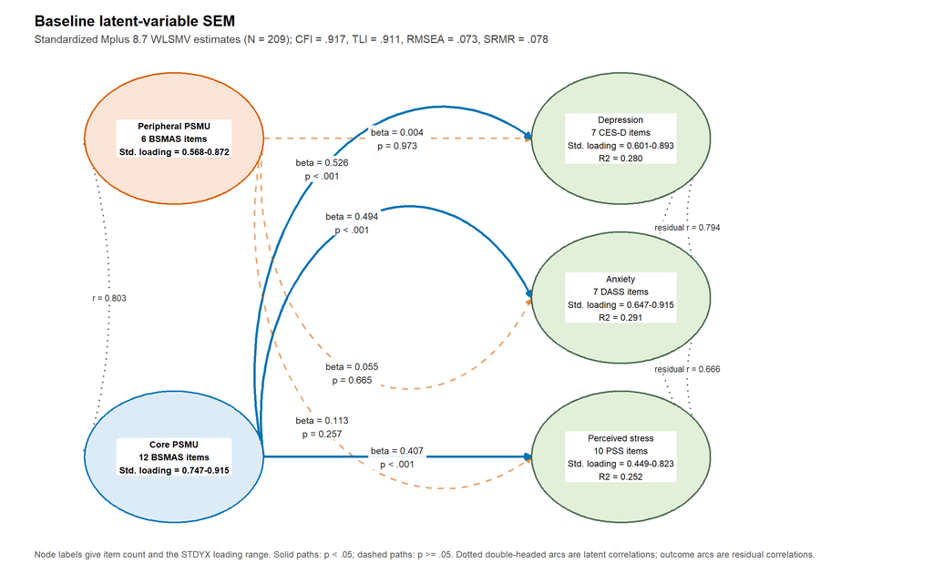

```r
sem_plot
```

# 9 Save the full-precision result bundle

```r
mplus_files <- dplyr::bind_rows(lapply(model_runs, function(run) {
  data.frame(
    model_id = run$model_id,
    role = names(run$paths),
    file = vapply(
      run$paths,
      function(path) normalizePath(path, winslash = "/", mustWork = TRUE),
      character(1)
    ),
    bytes = as.numeric(file.info(unname(run$paths))$size),
    md5 = unname(tools::md5sum(unname(run$paths))),
    stringsAsFactors = FALSE
  )
}))

stopifnot(
  nrow(mplus_files) == 6L,
  all(mplus_files$bytes > 0),
  all(file.exists(mplus_files$file))
)

knitr::kable(mplus_files)
```

|  | model_id | role | file | bytes | md5 |
| --- | --- | --- | --- | --- | --- |
| data…1 | Measurement_5Factor | data | G:/2026_[8]_PSMU_Daily_CorePeripheral/Step_2_Measurement_Models/mplus/s2_4/s2_4_measurement_5factor.dat | 17765 | cd7f2df59ef9863d93f476d798f5110b |
| input…2 | Measurement_5Factor | input | G:/2026_[8]_PSMU_Daily_CorePeripheral/Step_2_Measurement_Models/mplus/s2_4/s2_4_measurement_5factor.inp | 753 | 6b1ff2018db0dc4c2b6b68e062d8d376 |
| output…3 | Measurement_5Factor | output | G:/2026_[8]_PSMU_Daily_CorePeripheral/Step_2_Measurement_Models/mplus/s2_4/s2_4_measurement_5factor.out | 212300 | 2bad8261ff7cff4fabb46d782bace324 |
| data…4 | Structural_CorePeripheral | data | G:/2026_[8]_PSMU_Daily_CorePeripheral/Step_2_Measurement_Models/mplus/s2_4/s2_4_structural_core_peripheral.dat | 17765 | cd7f2df59ef9863d93f476d798f5110b |
| input…5 | Structural_CorePeripheral | input | G:/2026_[8]_PSMU_Daily_CorePeripheral/Step_2_Measurement_Models/mplus/s2_4/s2_4_structural_core_peripheral.inp | 776 | 89d45f78fa20307dc62c60c5102f7c70 |
| output…6 | Structural_CorePeripheral | output | G:/2026_[8]_PSMU_Daily_CorePeripheral/Step_2_Measurement_Models/mplus/s2_4/s2_4_structural_core_peripheral.out | 212878 | 94ce3b981051a718c9fd2abc3081f598 |

# 10 Export the review workbook

```r
round_numeric_columns <- function(data, digits = 4L) {
  data |>
    dplyr::mutate(dplyr::across(where(is.numeric), ~ round(.x, digits))) |>
    dplyr::mutate(dplyr::across(where(is.factor), as.character))
}

workbook_sheets <- list(
  Model_Fit = round_numeric_columns(model_fit),
  Structural_Paths = round_numeric_columns(structural_paths),
  Factor_Relations = round_numeric_columns(factor_relations),
  Loadings = round_numeric_columns(loadings),
  Diagnostics = round_numeric_columns(diagnostics)
)

bruceR::export(
  workbook_sheets,
  file = table_file,
  overwrite = TRUE,
  verbose = FALSE
)

workbook <- openxlsx::loadWorkbook(table_file)
header_style <- openxlsx::createStyle(
  fontName = "Arial",
  fontSize = 10,
  fontColour = "#FFFFFF",
  fgFill = "#1F4E78",
  textDecoration = "bold",
  halign = "center",
  valign = "center",
  wrapText = TRUE,
  border = "bottom",
  borderColour = "#163A5C"
)
decimal_style <- openxlsx::createStyle(numFmt = "0.0000")
integer_style <- openxlsx::createStyle(numFmt = "#,##0")
significant_style <- openxlsx::createStyle(fgFill = "#E2F0D9")
integer_columns <- c(
  "observations",
  "free_parameters",
  "df",
  "warnings_n",
  "errors_n",
  "item_order"
)

for (sheet_name in names(workbook_sheets)) {
  sheet_data <- workbook_sheets[[sheet_name]]
  n_rows <- nrow(sheet_data)
  n_columns <- ncol(sheet_data)

  openxlsx::addStyle(
    workbook,
    sheet = sheet_name,
    style = header_style,
    rows = 1,
    cols = seq_len(n_columns),
    gridExpand = TRUE,
    stack = TRUE
  )
  openxlsx::setRowHeights(workbook, sheet_name, rows = 1, heights = 32)
  openxlsx::freezePane(workbook, sheet_name, firstRow = TRUE)
  openxlsx::addFilter(workbook, sheet_name, rows = 1, cols = seq_len(n_columns))
  openxlsx::showGridLines(workbook, sheet_name, showGridLines = FALSE)

  widths <- vapply(seq_len(n_columns), function(index) {
    values <- c(names(sheet_data)[index], as.character(sheet_data[[index]]))
    values[is.na(values)] <- ""
    min(36, max(10, max(nchar(values), na.rm = TRUE) + 2))
  }, numeric(1))
  openxlsx::setColWidths(
    workbook,
    sheet = sheet_name,
    cols = seq_len(n_columns),
    widths = widths
  )

  if (n_rows > 0L) {
    numeric_indices <- which(vapply(sheet_data, is.numeric, logical(1)))
    integer_indices <- which(names(sheet_data) %in% integer_columns)
    decimal_indices <- setdiff(numeric_indices, integer_indices)
    if (length(integer_indices)) {
      openxlsx::addStyle(
        workbook,
        sheet = sheet_name,
        style = integer_style,
        rows = 2:(n_rows + 1L),
        cols = integer_indices,
        gridExpand = TRUE,
        stack = TRUE
      )
    }
    if (length(decimal_indices)) {
      openxlsx::addStyle(
        workbook,
        sheet = sheet_name,
        style = decimal_style,
        rows = 2:(n_rows + 1L),
        cols = decimal_indices,
        gridExpand = TRUE,
        stack = TRUE
      )
    }
  }
}

if ("standardized_p" %in% names(workbook_sheets$Structural_Paths)) {
  significant_rows <- which(
    workbook_sheets$Structural_Paths$standardized_p < .05
  ) + 1L
  if (length(significant_rows)) {
    openxlsx::addStyle(
      workbook,
      sheet = "Structural_Paths",
      style = significant_style,
      rows = significant_rows,
      cols = seq_len(ncol(workbook_sheets$Structural_Paths)),
      gridExpand = TRUE,
      stack = TRUE
    )
  }
}

for (sheet_name in names(workbook_sheets)) {
  openxlsx::pageSetup(
    workbook,
    sheet = sheet_name,
    orientation = "landscape",
    fitToWidth = 1,
    fitToHeight = 0
  )
}

openxlsx::saveWorkbook(workbook, table_file, overwrite = TRUE)

repair_orphan_drawing_relationships <- function(xlsx_file) {
  repair_dir <- tempfile("s2_4_xlsx_repair_")
  dir.create(repair_dir)
  on.exit(unlink(repair_dir, recursive = TRUE, force = TRUE), add = TRUE)

  utils::unzip(xlsx_file, exdir = repair_dir)
  relationship_directory <- file.path(
    repair_dir,
    "xl",
    "worksheets",
    "_rels"
  )
  if (!dir.exists(relationship_directory)) return(0L)
  relationship_files <- list.files(
    relationship_directory,
    pattern = "\\.rels$",
    full.names = TRUE
  )
  if (!length(relationship_files)) return(0L)

  orphan_pattern <- paste0(
    '<Relationship[^>]+Type="http://schemas\\.openxmlformats\\.org/',
    'officeDocument/2006/relationships/(drawing|vmlDrawing)"[^>]*/>'
  )
  removed_relationships <- 0L
  for (relationship_file in relationship_files) {
    xml_text <- paste(readLines(relationship_file, warn = FALSE), collapse = "\n")
    matches <- gregexpr(orphan_pattern, xml_text, perl = TRUE)[[1L]]
    removed_relationships <- removed_relationships +
      if (identical(matches, -1L)) 0L else length(matches)
    writeLines(
      gsub(orphan_pattern, "", xml_text, perl = TRUE),
      relationship_file,
      useBytes = TRUE
    )
  }
  if (removed_relationships == 0L) return(0L)

  repaired_file <- tempfile(fileext = ".xlsx")
  archive_members <- list.files(
    repair_dir,
    recursive = TRUE,
    all.files = TRUE,
    no.. = TRUE
  )
  zip::zipr(
    zipfile = repaired_file,
    files = archive_members,
    root = repair_dir,
    include_directories = FALSE,
    mode = "mirror"
  )
  stopifnot(file.exists(repaired_file), file.info(repaired_file)$size > 0)
  stopifnot(file.copy(repaired_file, xlsx_file, overwrite = TRUE))
  removed_relationships
}

orphan_relationships_removed <- repair_orphan_drawing_relationships(table_file)
stopifnot(
  file.exists(table_file),
  file.info(table_file)$size > 0,
  identical(openxlsx::getSheetNames(table_file), names(workbook_sheets))
)
```

# 11 Reload and verify the workbook

```r
expected_sheets <- names(workbook_sheets)
stopifnot(identical(readxl::excel_sheets(table_file), expected_sheets))

workbook_reload <- lapply(expected_sheets, function(sheet_name) {
  as.data.frame(readxl::read_excel(table_file, sheet = sheet_name))
})
names(workbook_reload) <- expected_sheets

for (sheet_name in expected_sheets) {
  stopifnot(
    nrow(workbook_reload[[sheet_name]]) == nrow(workbook_sheets[[sheet_name]]),
    ncol(workbook_reload[[sheet_name]]) == ncol(workbook_sheets[[sheet_name]]),
    identical(names(workbook_reload[[sheet_name]]), names(workbook_sheets[[sheet_name]]))
  )
}

stopifnot(
  nrow(workbook_reload$Model_Fit) == 2L,
  nrow(workbook_reload$Structural_Paths) == 6L,
  nrow(workbook_reload$Factor_Relations) == 14L,
  nrow(workbook_reload$Loadings) == 84L,
  nrow(workbook_reload$Diagnostics) == 2L,
  all(workbook_reload$Diagnostics$technical_checks_passed)
)

workbook_audit <- data.frame(
  sheet = expected_sheets,
  rows = vapply(workbook_reload, nrow, integer(1)),
  columns = vapply(workbook_reload, ncol, integer(1)),
  stringsAsFactors = FALSE
)

knitr::kable(workbook_audit)
```

|  | sheet | rows | columns |
| --- | --- | --- | --- |
| Model_Fit | Model_Fit | 2 | 18 |
| Structural_Paths | Structural_Paths | 6 | 15 |
| Factor_Relations | Factor_Relations | 14 | 13 |
| Loadings | Loadings | 84 | 22 |
| Diagnostics | Diagnostics | 2 | 16 |

# 12 Save and reload the canonical S2.4 RDA

```r
fit_s2_8_baseline_sem <- list(
  metadata = list(
    generated_by = "Step_2_Measurement_Models/S2_4_BaselineSEM_PSMU_PsychologicalDistress.Rmd",
    input_file = "Res_2_Data_for_Analysis/dat_step2_measurement.rda",
    input_md5 = unname(tools::md5sum(measurement_file)),
    mplus_version = "8.7",
    estimator = "WLSMV",
    parameterization = "DELTA",
    participants = 209L,
    workbook = "Res_3_Results/Table_S2_4_BaselineSEM_PSMU_PsychologicalDistress.xlsx",
    workbook_md5 = unname(tools::md5sum(table_file)),
    figure = "Res_3_Results/Figure_S2_4_BaselineSEM_PSMU_PsychologicalDistress.svg",
    figure_md5 = unname(tools::md5sum(figure_file)),
    figure_generated_with = paste0(
      "tidySEM ",
      packageVersion("tidySEM")
    ),
    s2_8_passed = all(diagnostics$technical_checks_passed) &&
      nrow(tidySEM::nodes(sem_graph_data)) == 5L &&
      nrow(tidySEM::edges(sem_graph_data)) == 10L &&
      grepl("<svg", svg_text, fixed = TRUE) &&
      !grepl("<image", svg_text, fixed = TRUE) &&
      !grepl("data:…", svg_text, fixed = TRUE)
  ),
  input_audit = input_audit,
  transformations = transformation_audit,
  variable_map = variable_map,
  model_plan = model_plan,
  model_syntax = lapply(model_specs, `[[`, "model"),
  model_fit = model_fit,
  fit_equivalence = fit_equivalence,
  loadings = loadings,
  factor_relations = factor_relations,
  structural_paths = structural_paths,
  diagnostics = diagnostics,
  sem_nodes = tidySEM::nodes(sem_graph_data),
  sem_edges = tidySEM::edges(sem_graph_data),
  figure_audit = figure_audit,
  workbook_audit = workbook_audit,
  mplus_files = mplus_files,
  parsed_models = lapply(model_runs, `[[`, "parsed")
)

save(
  fit_s2_8_baseline_sem,
  file = result_file,
  compress = "xz",
  version = 3
)

verification_environment <- new.env(parent = emptyenv())
verified_objects <- load(result_file, envir = verification_environment)
stopifnot(
  identical(verified_objects, "fit_s2_8_baseline_sem"),
  isTRUE(verification_environment$fit_s2_8_baseline_sem$metadata$s2_8_passed),
  identical(
    verification_environment$fit_s2_8_baseline_sem$metadata$input_md5,
    unname(tools::md5sum(measurement_file))
  ),
  identical(
    verification_environment$fit_s2_8_baseline_sem$metadata$workbook_md5,
    unname(tools::md5sum(table_file))
  ),
  identical(
    verification_environment$fit_s2_8_baseline_sem$metadata$figure_md5,
    unname(tools::md5sum(figure_file))
  ),
  nrow(verification_environment$fit_s2_8_baseline_sem$structural_paths) == 6L,
  nrow(verification_environment$fit_s2_8_baseline_sem$sem_nodes) == 5L,
  nrow(verification_environment$fit_s2_8_baseline_sem$sem_edges) == 10L
)

artifact_audit <- data.frame(
  file = c(
    "Res_2_Data_for_Analysis/fit_s2_8_baseline_sem.rda",
    "Res_3_Results/Table_S2_4_BaselineSEM_PSMU_PsychologicalDistress.xlsx",
    "Res_3_Results/Figure_S2_4_BaselineSEM_PSMU_PsychologicalDistress.svg"
  ),
  bytes = as.numeric(file.info(c(result_file, table_file, figure_file))$size),
  md5 = unname(tools::md5sum(c(result_file, table_file, figure_file))),
  stringsAsFactors = FALSE
)

stopifnot(all(artifact_audit$bytes > 0))
knitr::kable(artifact_audit)
```

| file | bytes | md5 |
| --- | --- | --- |
| Res_2_Data_for_Analysis/fit_s2_8_baseline_sem.rda | 37904 | 3b14b647fc066749799a79a7818823e2 |
| Res_3_Results/Table_S2_4_BaselineSEM_PSMU_PsychologicalDistress.xlsx | 26138 | 76e91754ceaef5dee31a601d8c50a455 |
| Res_3_Results/Figure_S2_4_BaselineSEM_PSMU_PsychologicalDistress.svg | 61204 | 7f1a4ed5a1503b6e9a8075d85075b0b5 |

# 13 Result summary

```r
path_summary <- structural_paths |>
  dplyr::mutate(
    significant = standardized_p < .05,
    direction = ifelse(standardized_estimate >= 0, "Positive", "Negative")
  ) |>
  dplyr::select(
    outcome_label,
    predictor_label,
    standardized_estimate,
    standardized_se,
    standardized_p,
    standardized_ci_lower,
    standardized_ci_upper,
    outcome_r_squared,
    direction,
    significant
  )

knitr::kable(path_summary, digits = 4)
```

| outcome_label | predictor_label | standardized_estimate | standardized_se | standardized_p | standardized_ci_lower | standardized_ci_upper | outcome_r_squared | direction | significant |
| --- | --- | --- | --- | --- | --- | --- | --- | --- | --- |
| Depression | Trait Peripheral PSMU | 0.004 | 0.112 | 0.973 | -0.215 | 0.223 | 0.280 | Positive | FALSE |
| Depression | Trait Core PSMU | 0.526 | 0.098 | 0.000 | 0.334 | 0.719 | 0.280 | Positive | TRUE |
| Anxiety | Trait Peripheral PSMU | 0.055 | 0.127 | 0.665 | -0.194 | 0.305 | 0.291 | Positive | FALSE |
| Anxiety | Trait Core PSMU | 0.494 | 0.108 | 0.000 | 0.282 | 0.706 | 0.291 | Positive | TRUE |
| Perceived stress | Trait Peripheral PSMU | 0.113 | 0.099 | 0.257 | -0.082 | 0.307 | 0.252 | Positive | FALSE |
| Perceived stress | Trait Core PSMU | 0.407 | 0.092 | 0.000 | 0.227 | 0.588 | 0.252 | Positive | TRUE |

The regression coefficients are mutually adjusted: each Core coefficient controls for Peripheral, and each Peripheral coefficient controls for Core. They are cross-sectional latent associations and must not be interpreted as causal effects. Statistical significance of one path and nonsignificance of another does not establish that the two coefficients differ; S2.4 does not test coefficient equality.